# STA 4102 RESEARCH PROJECT REPORT

##Statistical Modeling and Technique

```r
#Hypothesis 1:
#An increase in Hours_Studied will significantly predict a higher Exam_Score.
# Simple linear regression for Hours_Studied vs Exam_Score
model_h1 <- lm(Exam_Score ~ Hours_Studied, data = data)

# Model Summary
summary(model_h1)
```

```
##
## Call:
## lm(formula = Exam_Score ~ Hours_Studied, data = data)
##
## Residuals:
##     Min      1Q  Median      3Q     Max
## -8.4212 -2.1352  0.0067  2.1509 12.4415
##
## Coefficients:
##                Estimate Std. Error t value Pr(>|t|)
## (Intercept)   61.414310   0.125466  489.49   <2e-16 ***
## Hours_Studied  0.286044   0.006021   47.51   <2e-16 ***
## ---
## Signif. codes:  0 '***' 0.001 '**' 0.01 '*' 0.05 '.' 0.1 ' ' 1
##
## Residual standard error: 2.912 on 6605 degrees of freedom
## Multiple R-squared:  0.2547, Adjusted R-squared:  0.2546
## F-statistic:  2257 on 1 and 6605 DF,  p-value: < 2.2e-16
```

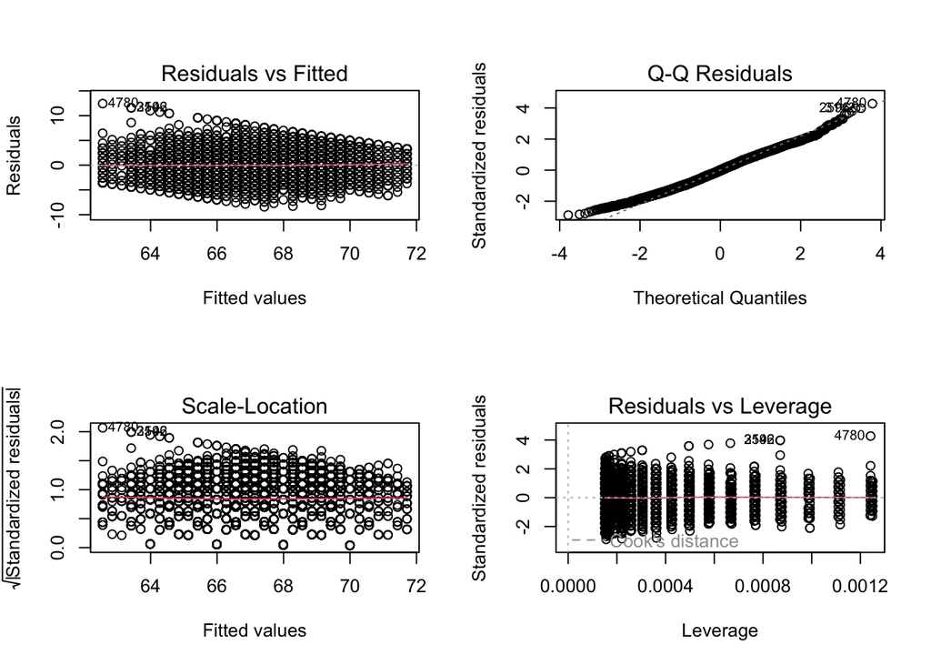

```r
# Diagnostic Plots to Check Assumptions
par(mfrow = c(2, 2))
plot(model_h1)
```

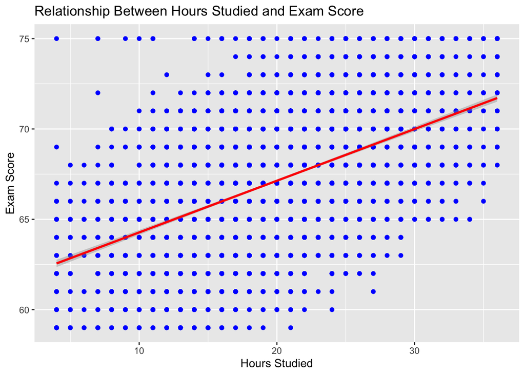

```r
# Visualization: Scatterplot with Regression Line
library(ggplot2)
ggplot(data, aes(x = Hours_Studied, y = Exam_Score)) +
  geom_point(color = "blue") +
  geom_smooth(method = "lm", se = TRUE, color = "red") +
  labs(title = "Relationship Between Hours Studied and Exam Score", x = "Hours Studied", y = "Exam Score")
```

The regression analysis establishes a significant positive relationship between Hours_Studied and Exam_Score (β=0.28, p<2×10^−16). The model indicates that each additional hour of study increases the exam score by approximately 0.28 points. Despite this, the 𝑅^2 value of 0.2547 reveals that Hours_Studied explains only 25.5% of the variance in exam scores, suggesting that additional factors, such as Attendance or Family_Income, may substantially influence performance.

Diagnostic assessments confirm no severe violations of regression assumptions. Residuals exhibit homoscedasticity and independence, with only minor deviations from normality observed in the Q-Q plot. Given the large sample size, these deviations are unlikely to materially affect results, though future analysis might explore nonlinear relationships or apply transformations to address any potential issues.

```r
#Hypothesis 2: Attendance is Positively Correlated with Exam Score

# Correlation Analysis
cor_attendance_exam <- cor(data$Attendance, data$Exam_Score, use = "complete.obs")
print(paste("Correlation between Attendance and Exam Score:", cor_attendance_exam))
```

```
## [1] "Correlation between Attendance and Exam Score: 0.660554792092198"
```

```r
# Simple Linear Regression
model_h2 <- lm(Exam_Score ~ Attendance, data = data)

# Model Summary
summary(model_h2)
```

```
##
## Call:
## lm(formula = Exam_Score ~ Attendance, data = data)
##
## Residuals:
##     Min      1Q  Median      3Q     Max
## -8.7974 -1.6750 -0.0444  1.5885 11.5344
##
## Coefficients:
##              Estimate Std. Error t value Pr(>|t|)
## (Intercept) 51.696147   0.218042   237.1   <2e-16 ***
## Attendance   0.192942   0.002698    71.5   <2e-16 ***
## ---
## Signif. codes:  0 '***' 0.001 '**' 0.01 '*' 0.05 '.' 0.1 ' ' 1
##
## Residual standard error: 2.532 on 6605 degrees of freedom
## Multiple R-squared:  0.4363, Adjusted R-squared:  0.4362
## F-statistic:  5113 on 1 and 6605 DF,  p-value: < 2.2e-16
```

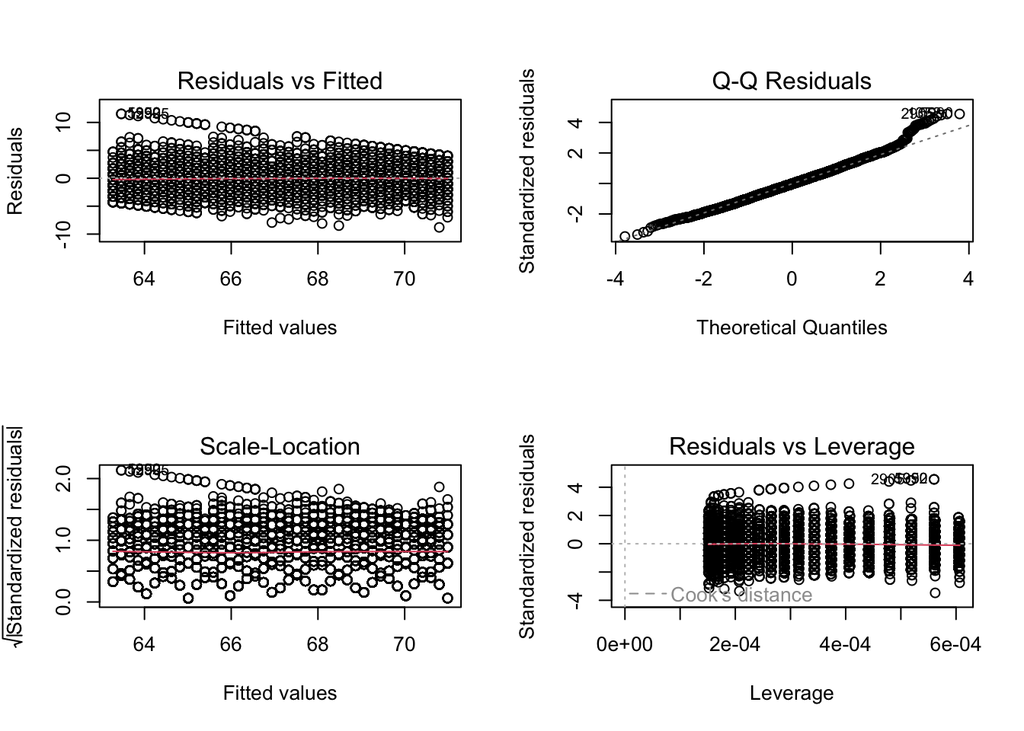

```r
# Residual Diagnostics
par(mfrow = c(2, 2))  # Set layout for diagnostic plots
plot(model_h2)
```

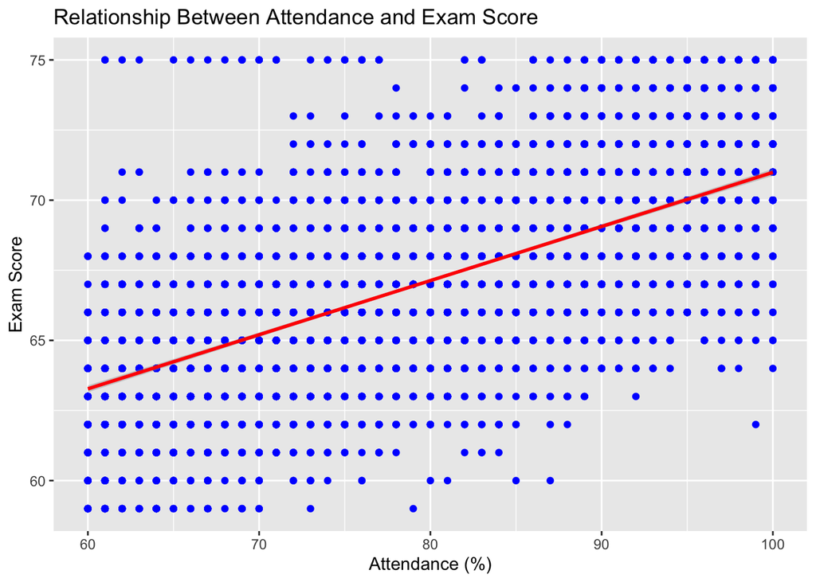

```r
# Visualization: Scatterplot with Regression Line
library(ggplot2)
ggplot(data, aes(x = Attendance, y = Exam_Score)) +
  geom_point(color = "blue") +
  geom_smooth(method = "lm", se = TRUE, color = "red") +
  labs(title = "Relationship Between Attendance and Exam Score",
       x = "Attendance (%)",
       y = "Exam Score")
```

```r
#Compare Exam_Score across groups of Attendance levels (e.g., high vs. low attendance):
data$Attendance_Group <- cut(data$Attendance, breaks = c(0, 50, 75, 100),
                             labels = c("Low", "Moderate", "High"))
aggregate(Exam_Score ~ Attendance_Group, data = data, mean)
```

```
##   Attendance_Group Exam_Score
## 1         Moderate   64.76385
## 2             High   68.60783
```

The analysis confirms a significant positive relationship between Attendance and Exam_Score, supporting the hypothesis that higher attendance rates are associated with better academic performance. The Pearson correlation coefficient (r=0.6605) indicates a moderately strong positive correlation, suggesting that students who attend class more consistently tend to achieve higher exam scores. This is further supported by the simple linear regression model, which predicts an increase of 0.19 points in Exam_Score for every 1% increase in Attendance (β=0.19,p<2×10^−16). The intercept of 51.70 indicates the expected Exam_Score for a student with 0% attendance, highlighting the substantial baseline contribution of attendance to academic success.